# Traitement des distances

Author

Victor Nunzi

Published

June 20, 2023

Script *Quarto* visant à traiter les distances obtenues en sortie de `detailed_itineraries`.

Date du dernier *render* : 2023-06-26

## Librairies et fonctions

```r
source("C:/Users/victo/OneDrive - ETS/MTR896/TRAVAIL/99_GitHub/MTR896/librairies/librairies.R")
source("C:/Users/victo/OneDrive - ETS/MTR896/TRAVAIL/99_GitHub/MTR896/fonctions/fonctions.R")
```

## 1 Données

On commence par charger l’ensemble des déplacements :

```r
depl_COMPLETE            <- readRDS("C:/Users/victo/OneDrive - ETS/MTR896/TRAVAIL/00_Donnees/deplacements/depl_COMPLETE.Rds")
depl_TRANSIT             <- readRDS("C:/Users/victo/OneDrive - ETS/MTR896/TRAVAIL/00_Donnees/deplacements/depl_TRANSIT.Rds")
RESULTS_CAR              <- read.csv("C:/Users/victo/OneDrive - ETS/MTR896/TRAVAIL/00_Donnees/distances/RESULTS_CAR.csv")
RESULTS_TRANSIT_1min     <- read.csv("C:/Users/victo/OneDrive - ETS/MTR896/TRAVAIL/00_Donnees/distances/RESULTS_TRANSIT_1min.csv")
RESULTS_TRANSIT_1min_WP  <- read.csv("C:/Users/victo/OneDrive - ETS/MTR896/TRAVAIL/00_Donnees/distances/RESULTS_TRANSIT_1min_WP.csv")
```

On *subset* les colonnes qui nous intéressent :

```r
depl_distances <- depl_COMPLETE %>%
  dplyr::select(
    c(
      ipere,
      m_numero,
      p_rang,
      d_orira8,
      d_desra8,
      d_modeseq,
      r5r_modelist,
      d_dist_straight
      )
    )
```

Nombre de déplacements : 296610

## 2 Traitements des itinéraires

### 2.1 Automobiles

On ajoute les distances réseau pour les déplacements en automobile uniquement :

```r
depl_distances$d_dist_car_ntwk <-
  RESULTS_CAR$total_distance[match(depl_distances$ipere,
                                   RESULTS_CAR$from_id)]
```

### 2.2 Transports en commun

```r
distances_TC <- RESULTS_TRANSIT_1min %>%
  dplyr::select(c(
    from_id, total_distance, segment, mode, distance
  )) %>%
  group_by(from_id, mode) %>%
  summarise(
    distance_mode = sum(distance)
  ) %>%
  pivot_wider(
    id_cols = from_id,
    names_from = mode,
    values_from = distance_mode
  )
```

Il ressort de ce traitement que `r5r` a très largement préféré la marche aux différents TC, ce qui est problématique car cela ne correspond à ce qui a été déclaré par les répondant(e)s.

En effet, on a :

- 40509 déplacements avec un résultat (97.6 %);
- 20402 déplacements comptent plus de 1 km de marche (49.2 %);
- 9108 déplacement sans utilisation du TC (21.9 %).

Pour pallier cela, deux solutions peuvent être envisagées :

1. pénaliser la marche (en termes de vitesse et de temps maximal par trajet) pour favoriser le TC;
2. calculer multiples options par trajet, et sélectionner par la suite celle qui correspond le mieux à la déclaration d’origine.

Plus simple à mettre en place et moins coûteuse en termes de temps de calcul, la première option sera explorée dans un premier temps.

Résultats de cette pénalité pour la marche :

```r
distances_TC_WP <- RESULTS_TRANSIT_1min_WP %>%
  dplyr::select(c(
    from_id, total_distance, segment, mode, distance
  )) %>%
  group_by(from_id, mode) %>%
  summarise(
    distance_mode = sum(distance)
  ) %>%
  pivot_wider(
    id_cols = from_id,
    names_from = mode,
    values_from = distance_mode
  )
```

- 38191 déplacements avec un résultat (92 %);
- 11849 déplacements comptent plus de 1 km de marche (28.5 %);
- 7244 déplacement sans utilisation du TC (17.5 %).

On a perdu de nombreux déplacements, on va donc compléter notre table avec pénalité à partir de notre table sans pénalité, pour les déplacements qui n’avaient pas de résultats :

```r
distances_TC_BIND <- rbind(distances_TC_WP,
                           subset(distances_TC, !(from_id %in% distances_TC_WP$from_id)))
```

Résumé :

- déplacements avec plus de 1 km de marche : 14151 (34.9 %);
- déplacements sans TC : 7506 (18.5 %).

## 3 Fusion des résultats

### 3.1 Fusion

On place dans un seul `dataframe` l’ensemble des distances :

```r
depl_distances$d_dist_car_ntwk <-
  ifelse(is.na(depl_distances$d_dist_car_ntwk),
         distances_TC_BIND$CAR[match(depl_distances$ipere, distances_TC_BIND$from_id)],
         depl_distances$d_dist_car_ntwk)


depl_distances$d_dist_bus_ntwk     <- distances_TC_BIND$BUS[match(depl_distances$ipere, distances_TC_BIND$from_id)]
depl_distances$d_dist_walk_ntwk    <- distances_TC_BIND$WALK[match(depl_distances$ipere, distances_TC_BIND$from_id)]
depl_distances$d_dist_subway_ntwk  <- distances_TC_BIND$SUBWAY[match(depl_distances$ipere, distances_TC_BIND$from_id)]
depl_distances$d_dist_rail_ntwk    <- distances_TC_BIND$RAIL[match(depl_distances$ipere, distances_TC_BIND$from_id)]
depl_distances$d_dist_bicycle_ntwk <- distances_TC_BIND$BICYCLE[match(depl_distances$ipere, distances_TC_BIND$from_id)]

depl_distances$d_dist_ntwk <-
  rowSums(depl_distances %>% dplyr::select(d_dist_car_ntwk:d_dist_bicycle_ntwk), na.rm = T)
```

On crée une nouvelle table en enlevant les déplacements qui n’ont pas donné de résultats dans `r5r` :

```r
depl_dist_RESULTS <- subset(depl_distances, d_dist_ntwk != 0)
```

Cela comprend 295088 déplacements (99.5 % du total).

### 3.2 Corrélation générale

**Coefficient de corrélation (Pearson) :**

```r
cor_full <- cor.test(depl_dist_RESULTS$d_dist_straight, depl_dist_RESULTS$d_dist_ntwk, conf.level = .95)
r_full <- round(unname(cor_full$estimate), 3)
```

```
[1] "r = 0.976"
```

**Régression linéaire sans condition sur l’ordonnée à l’origine :**

```r
lm_full <- lm(d_dist_ntwk ~ d_dist_straight, depl_dist_RESULTS)

slope_full <- round(unname(lm_full$coefficients[2]), 3)
inter_full <- round(unname(lm_full$coefficients[1]))

depl_dist_RESULTS$predi <- depl_dist_RESULTS$d_dist_straight*slope_full + inter_full

rss      <- sum((depl_dist_RESULTS$predi - depl_dist_RESULTS$d_dist_ntwk) ^ 2)  ## residual sum of squares
tss      <- sum((depl_dist_RESULTS$d_dist_ntwk - mean(depl_dist_RESULTS$d_dist_ntwk)) ^ 2)  ## total sum of squares
rsq_full <- round(1 - rss/tss, 3)
```

```
[1] "slope = 1.411"
```

```
[1] "intercept = 660"
```

```
[1] "R^2 = 0.953"
```

**Régression linéaire en forçant une ordonnée à l’origine de 0 :**

```r
lm_full_i0 <- train(d_dist_ntwk ~ d_dist_straight,
                    data = depl_dist_RESULTS,
                    method  = "lm",
                    tuneGrid  = expand.grid(intercept = FALSE))

slope_full_i0 <- round(unname(lm_full_i0$finalModel$coefficients), 3)

depl_dist_RESULTS$predi_i0 <- depl_dist_RESULTS$d_dist_straight*slope_full_i0

rss         <- sum((depl_dist_RESULTS$predi_i0 - depl_dist_RESULTS$d_dist_ntwk) ^ 2)          ## residual sum of squares
tss         <- sum((depl_dist_RESULTS$d_dist_ntwk - mean(depl_dist_RESULTS$d_dist_ntwk)) ^ 2) ## total sum of squares
rsq_full_i0 <- round(1 - rss/tss, 3)
```

```
[1] "slope = 1.443"
```

```
[1] "intercept = 0"
```

```
[1] "R^2 = 0.952"
```

**Graphique (n = 295088) :**

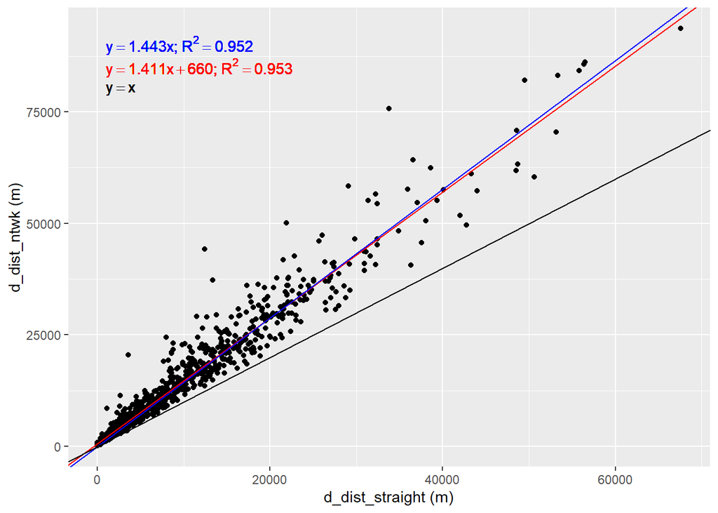

```r
set.seed(20230621)

ggplot(depl_dist_RESULTS[sample(nrow(depl_dist_RESULTS), 1000),], aes(d_dist_straight, d_dist_ntwk)) +
  geom_point() +
  geom_abline(slope = slope_full,    intercept = inter_full, color = "red") +
  geom_abline(slope = slope_full_i0, intercept = 0,          color = "blue") +
  geom_abline(slope = 1) +
  geom_text(aes(x = 1000, y = 90000), color = "blue", label = paste0("y == ",
                                                                     as.character(slope_full_i0),
                                                                     "*x*\";\"~R^2 ==",
                                                                     as.character(rsq_full_i0)), parse = T, hjust = 0) +
  geom_text(aes(x = 1000, y = 85000), color = "red",  label = paste0("y == ",
                                                                     as.character(slope_full),
                                                                     "*x + ",
                                                                     as.character(inter_full),
                                                                     "*\";\"~R^2 ==",
                                                                     as.character(rsq_full)), parse = T, hjust = 0) +
  geom_text(aes(x = 1000, y = 80000), label = "y == x", parse = T, hjust = 0) +
  labs(x = "d_dist_straight (m)", y = "d_dist_ntwk (m)")
```

### 3.3 Modes exclusifs

On attribue à chaque itinéraire un mode exclusif parmi les modes suivants :

- voiture;
- bus;
- métro;
- train;
- vélo;
- marche;
- multimode.

```r
depl_dist_RESULTS[is.na(depl_dist_RESULTS)] <- 0

depl_dist_RESULTS$i_nbmodescat_pasmarche <-
  rowSums(
    depl_dist_RESULTS %>%
      dplyr::select(c(d_dist_car_ntwk:d_dist_bicycle_ntwk)) %>%
      dplyr::select(-d_dist_walk_ntwk) %>%
      mutate_all(~ . > 0)
  )

depl_dist_RESULTS$i_modeexclu <-
  case_when(
    depl_dist_RESULTS$i_nbmodescat_pasmarche == 0 ~ "marche",
    depl_dist_RESULTS$i_nbmodescat_pasmarche >= 2 ~ "multi",
    depl_dist_RESULTS$i_nbmodescat_pasmarche == 1 ~
      case_when(
        depl_dist_RESULTS$d_dist_car_ntwk     > 0 ~ "voiture",
        depl_dist_RESULTS$d_dist_bus_ntwk     > 0 ~ "bus",
        depl_dist_RESULTS$d_dist_subway_ntwk  > 0 ~ "metro",
        depl_dist_RESULTS$d_dist_rail_ntwk    > 0 ~ "train",
        depl_dist_RESULTS$d_dist_bicycle_ntwk > 0 ~ "velo"
      )
  )

print(table(depl_dist_RESULTS$i_modeexclu, useNA = "ifany"))
```

```
    bus  marche   metro   multi   train    velo voiture
  17419     662     485   14069    1030      17  261406
```

```r
print(round(table(depl_dist_RESULTS$i_modeexclu, useNA = "ifany")/sum(table(depl_dist_RESULTS$i_modeexclu, useNA = "ifany")), 3))
```

```
    bus  marche   metro   multi   train    velo voiture
  0.059   0.002   0.002   0.048   0.003   0.000   0.886
```

## 4 Analyse des itinéraires automobiles

*Subset :*

```r
itineraires_voiture <- subset(depl_dist_RESULTS, i_modeexclu == "voiture")
```

**Coefficient de corrélation (Pearson) :**

```r
cor_car <- cor.test(itineraires_voiture$d_dist_straight, itineraires_voiture$d_dist_ntwk, conf.level = .95)
r_car <- round(unname(cor_car$estimate), 3)
```

```
[1] "r = 0.978"
```

**Régression linéaire sans condition sur l’ordonnée à l’origine :**

```r
lm_car <- lm(d_dist_ntwk ~ d_dist_straight, itineraires_voiture)

slope_car <- round(unname(lm_car$coefficients[2]), 3)
inter_car <- round(unname(lm_car$coefficients[1]))

itineraires_voiture$predi <- itineraires_voiture$d_dist_straight*slope_car + inter_car

rss     <- sum((itineraires_voiture$predi       - itineraires_voiture$d_dist_ntwk) ^ 2)          ## residual sum of squares
tss     <- sum((itineraires_voiture$d_dist_ntwk - mean(itineraires_voiture$d_dist_ntwk)) ^ 2) ## total sum of squares
rsq_car <- round(1 - rss/tss, 3)
```

```
[1] "slope = 1.415"
```

```
[1] "intercept = 585"
```

```
[1] "R^2 = 0.957"
```

**Régression linéaire en forçant une ordonnée à l’origine de 0 :**

```r
lm_car_i0 <- train(d_dist_ntwk ~ d_dist_straight,
                    data = itineraires_voiture,
                    method  = "lm",
                    tuneGrid  = expand.grid(intercept = FALSE))

slope_car_i0 <- round(unname(lm_car_i0$finalModel$coefficients), 3)

itineraires_voiture$predi_i0 <- itineraires_voiture$d_dist_straight*slope_car_i0

rss        <- sum((itineraires_voiture$predi_i0    - itineraires_voiture$d_dist_ntwk) ^ 2)       ## residual sum of squares
tss        <- sum((itineraires_voiture$d_dist_ntwk - mean(itineraires_voiture$d_dist_ntwk)) ^ 2) ## total sum of squares
rsq_car_i0 <- round(1 - rss/tss, 3)
```

```
[1] "slope = 1.443"
```

```
[1] "intercept = 0"
```

```
[1] "R^2 = 0.956"
```

**Graphique (n = 261406) :**

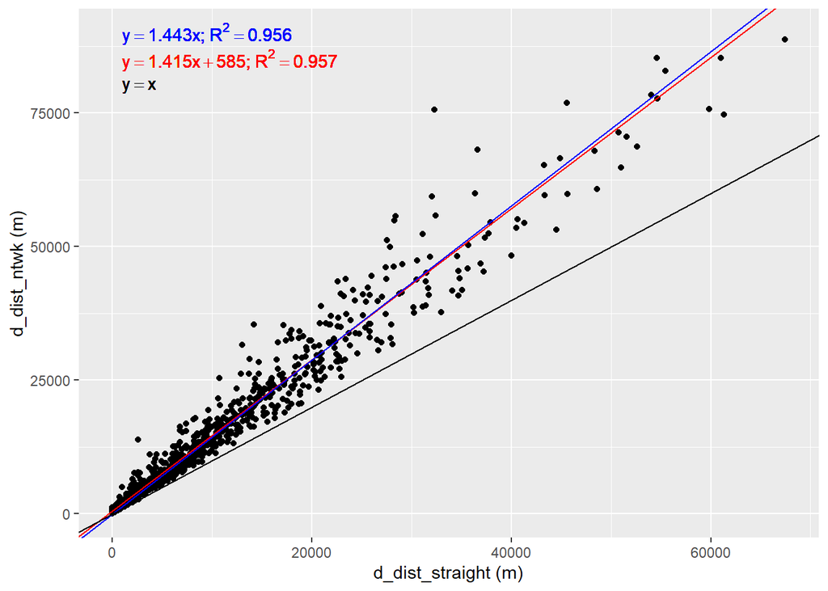

```r
set.seed(20230621)

ggplot(itineraires_voiture[sample(nrow(itineraires_voiture), 1000),], aes(d_dist_straight, d_dist_ntwk)) +
  geom_point() +
  geom_abline(slope = slope_car,    intercept = inter_car, color = "red") +
  geom_abline(slope = slope_car_i0, intercept = 0,         color = "blue") +
  geom_abline(slope = 1) +
  geom_text(aes(x = 1000, y = 90000), color = "blue", label = paste0("y == ",
                                                                     as.character(slope_car_i0),
                                                                     "*x*\";\"~R^2 ==",
                                                                     as.character(rsq_car_i0)), parse = T, hjust = 0) +
  geom_text(aes(x = 1000, y = 85000), color = "red",  label = paste0("y == ",
                                                                     as.character(slope_car),
                                                                     "*x + ",
                                                                     as.character(inter_car),
                                                                     "*\";\"~R^2 ==",
                                                                     as.character(rsq_car)), parse = T, hjust = 0) +
  geom_text(aes(x = 1000, y = 80000), label = "y == x", parse = T, hjust = 0) +
  labs(x = "d_dist_straight (m)", y = "d_dist_ntwk (m)")
```

## 5 Analyse des itinéraires impliquant le TC

*Subset :*

```r
itineraires_tc <- subset(depl_dist_RESULTS,
                         d_dist_bus_ntwk      > 0 |
                           d_dist_subway_ntwk > 0 |
                           d_dist_rail_ntwk   > 0)
```

**Coefficient de corrélation (Pearson) :**

```r
cor_tc <- cor.test(itineraires_tc$d_dist_straight, itineraires_tc$d_dist_ntwk, conf.level = .95)
r_tc <- round(unname(cor_tc$estimate), 3)
```

```
[1] "r = 0.935"
```

**Régression linéaire sans condition sur l’ordonnée à l’origine :**

```r
lm_tc <- lm(d_dist_ntwk ~ d_dist_straight, itineraires_tc)

slope_tc <- round(unname(lm_tc$coefficients[2]), 3)
inter_tc <- round(unname(lm_tc$coefficients[1]))

itineraires_tc$predi <- itineraires_tc$d_dist_straight*slope_tc + inter_tc

rss     <- sum((itineraires_tc$predi       - itineraires_tc$d_dist_ntwk) ^ 2)       ## residual sum of squares
tss     <- sum((itineraires_tc$d_dist_ntwk - mean(itineraires_tc$d_dist_ntwk)) ^ 2) ## total sum of squares
rsq_tc  <- round(1 - rss/tss, 3)
```

```
[1] "slope = 1.325"
```

```
[1] "intercept = 1665"
```

```
[1] "R^2 = 0.874"
```

**Régression linéaire en forçant une ordonnée à l’origine de 0 :**

```r
lm_tc_i0 <- train(d_dist_ntwk ~ d_dist_straight,
                  data = itineraires_tc,
                  method  = "lm",
                  tuneGrid  = expand.grid(intercept = FALSE))

slope_tc_i0 <- round(unname(lm_tc_i0$finalModel$coefficients), 3)

itineraires_tc$predi_i0 <- itineraires_tc$d_dist_straight*slope_tc_i0

rss        <- sum((itineraires_tc$predi_i0    - itineraires_tc$d_dist_ntwk) ^ 2)       ## residual sum of squares
tss        <- sum((itineraires_tc$d_dist_ntwk - mean(itineraires_tc$d_dist_ntwk)) ^ 2) ## total sum of squares
rsq_tc_i0 <- round(1 - rss/tss, 3)
```

```
[1] "slope = 1.447"
```

```
[1] "intercept = 0"
```

```
[1] "R^2 = 0.862"
```

**Graphique (n = 33003) :**

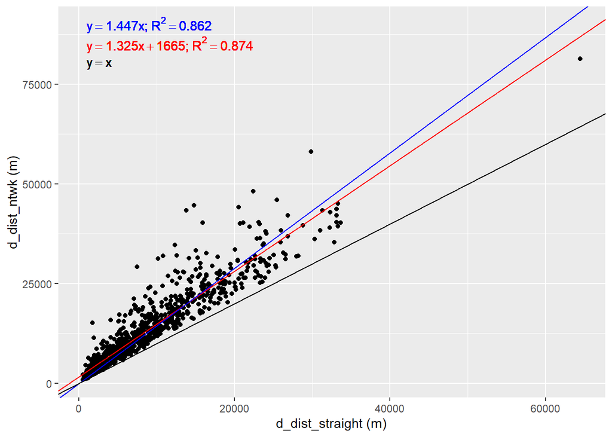

```r
set.seed(20230621)

ggplot(itineraires_tc[sample(nrow(itineraires_tc), 1000),], aes(d_dist_straight, d_dist_ntwk)) +
  geom_point() +
  geom_abline(slope = slope_tc,    intercept = inter_tc, color = "red") +
  geom_abline(slope = slope_tc_i0, intercept = 0,         color = "blue") +
  geom_abline(slope = 1) +
  geom_text(aes(x = 1000, y = 90000), color = "blue", label = paste0("y == ",
                                                                     as.character(slope_tc_i0),
                                                                     "*x*\";\"~R^2 ==",
                                                                     as.character(rsq_tc_i0)), parse = T, hjust = 0) +
  geom_text(aes(x = 1000, y = 85000), color = "red",  label = paste0("y == ",
                                                                     as.character(slope_tc),
                                                                     "*x + ",
                                                                     as.character(inter_tc),
                                                                     "*\";\"~R^2 ==",
                                                                     as.character(rsq_tc)), parse = T, hjust = 0) +
  geom_text(aes(x = 1000, y = 80000), label = "y == x", parse = T, hjust = 0) +
  labs(x = "d_dist_straight (m)", y = "d_dist_ntwk (m)")
```

## 6 Résumé par modes

On réalise les régressions linéaires pour chaque mode exclusif :

```r
# On groupe par modes :
gc()
ts1_sumbymodes <- Sys.time()

summary_bymodes <- depl_dist_RESULTS %>%
  group_by(i_modeexclu) %>%
  summarise(n = n()) %>%
  mutate(
    coeffs = sapply(
      i_modeexclu,
      function(modeexclu){
        temp.subset <- subset(depl_dist_RESULTS, i_modeexclu == modeexclu)

        lm <- train(d_dist_ntwk ~ d_dist_straight,
                    data = temp.subset,
                    method  = "lm",
                    tuneGrid  = expand.grid(intercept = FALSE))

        slope <- round(unname(lm$finalModel$coefficients), 3)

        temp.subset$predi <- temp.subset$d_dist_straight*slope

        rss <- sum((temp.subset$predi       - temp.subset$d_dist_ntwk) ^ 2)       ## residual sum of squares
        tss <- sum((temp.subset$d_dist_ntwk - mean(temp.subset$d_dist_ntwk)) ^ 2) ## total sum of squares
        rsq <- round(1 - rss/tss, 3)

        return(paste(slope, rsq))
      }
    )
  )

ts2_sumbymodes <- Sys.time()

print(ts2_sumbymodes - ts1_sumbymodes)

save(ts1_sumbymodes, ts2_sumbymodes, summary_bymodes,
     file = "C:/Users/victo/OneDrive - ETS/MTR896/TRAVAIL/99_GitHub/MTR896/distances/sumbymodes.RData")
```

| i_modeexclu | n | coeffs |
| --- | --- | --- |
| bus | 17419 | 1.566 0.833 |
| marche | 662 | 1.32 0.919 |
| metro | 485 | 1.572 0.769 |
| multi | 14069 | 1.433 0.856 |
| train | 1030 | 1.204 0.906 |
| velo | 17 | 1.389 0.979 |
| voiture | 261406 | 1.443 0.956 |

## 7 Résumé par régions d’origines et de destinations

```r
# On groupe par modes :
gc()
ts1_sumbyra <- Sys.time()

summary_byra <- depl_dist_RESULTS %>%
  group_by(d_orira8, d_desra8) %>%
  summarise(n = n()) %>%
  mutate(
    coeffs = sapply(
      paste(d_orira8, d_desra8),
      function(ra_od){
        temp.subset <- subset(depl_dist_RESULTS, paste(d_orira8, d_desra8) == ra_od)

        lm <- train(d_dist_ntwk ~ d_dist_straight,
                    data = temp.subset,
                    method  = "lm",
                    tuneGrid  = expand.grid(intercept = FALSE))

        slope <- round(unname(lm$finalModel$coefficients), 3)

        temp.subset$predi <- temp.subset$d_dist_straight*slope

        rss <- sum((temp.subset$predi       - temp.subset$d_dist_ntwk) ^ 2)       ## residual sum of squares
        tss <- sum((temp.subset$d_dist_ntwk - mean(temp.subset$d_dist_ntwk)) ^ 2) ## total sum of squares
        rsq <- round(1 - rss/tss, 3)

        return(paste(slope, rsq))
      }
    )
  )

summary_byra_wide <- summary_byra %>%
  dplyr::select(-n) %>%
  pivot_wider(names_from = "d_desra8", values_from = "coeffs")

ts2_sumbyra <- Sys.time()

print(ts2_sumbyra - ts1_sumbyra)

save(ts1_sumbyra, ts2_sumbyra, summary_byra, summary_byra_wide,
     file = "C:/Users/victo/OneDrive - ETS/MTR896/TRAVAIL/99_GitHub/MTR896/distances/sumbyRA8.RData")
```

| d_orira8 | 1 | 2 | 3 | 4 | 5 | 6 | 7 | 8 |
| --- | --- | --- | --- | --- | --- | --- | --- | --- |
| 1 | 1.546 0.807 | 1.362 0.871 | 1.31 0.743 | 1.382 0.898 | 1.644 0.803 | 1.395 0.696 | 1.384 0.832 | 1.436 0.807 |
| 2 | 1.351 0.87 | 1.448 0.926 | 1.349 0.935 | 1.465 0.918 | 1.596 0.76 | 1.492 0.891 | 1.426 0.882 | 1.447 0.835 |
| 3 | 1.305 0.71 | 1.365 0.94 | 1.461 0.924 | 1.395 0.863 | 1.609 0.761 | 1.514 0.889 | 1.477 0.896 | 1.533 0.808 |
| 4 | 1.343 0.929 | 1.383 0.928 | 1.269 0.863 | 1.493 0.916 | 1.451 0.86 | 1.616 0.739 | 1.472 0.82 | 1.441 0.863 |
| 5 | 1.587 0.798 | 1.556 0.726 | 1.582 0.734 | 1.522 0.685 | 1.525 0.916 | 1.45 0.817 | 1.517 0.86 | 1.465 0.913 |
| 6 | 1.381 0.742 | 1.457 0.917 | 1.546 0.869 | 1.591 0.808 | 1.488 0.775 | 1.447 0.912 | 1.467 0.953 | 1.558 0.671 |
| 7 | 1.34 0.85 | 1.351 0.912 | 1.444 0.907 | 1.483 0.848 | 1.451 0.911 | 1.447 0.919 | 1.451 0.96 | 1.611 0.071 |
| 8 | 1.364 0.755 | 1.39 0.813 | 1.431 0.795 | 1.43 0.843 | 1.403 0.93 | 1.501 0.875 | 1.569 0.158 | 1.445 0.949 |

```r
summary_byra$i_d <-
  sapply(summary_byra$coeffs,
         function(string){
           i_d <- str_split(string, " ")[[1]][1]
           return(as.numeric(i_d))
         })

summary_byra$rsq <-
  sapply(summary_byra$coeffs,
         function(string){
           rsq <- str_split(string, " ")[[1]][2]
           return(as.numeric(rsq))
         })


summary_byra$cross_water <-
  case_when(
    summary_byra$d_orira8 == summary_byra$d_desra8          ~ 0,
    summary_byra$d_orira8 <= 4 & summary_byra$d_desra8 <= 4 ~ 0,
    summary_byra$d_orira8 == 5 & summary_byra$d_desra8 == 8 ~ 0,
    summary_byra$d_orira8 == 8 & summary_byra$d_desra8 <= 5 ~ 0,
    TRUE ~ 1
  )
```

Résumé général :

```r
print(summary(summary_byra$i_d))
```

```
   Min. 1st Qu.  Median    Mean 3rd Qu.    Max.
  1,269   1,394   1,451   1,460   1,518   1,644
```

```r
print(summary(summary_byra$rsq))
```

```
   Min. 1st Qu.  Median    Mean 3rd Qu.    Max.
 0,0710  0,7973  0,8615  0,8246  0,9123  0,9600
```

Pas d’étendue d’eau :

```r
print(summary(subset(summary_byra, !cross_water)$i_d))
```

```
   Min. 1st Qu.  Median    Mean 3rd Qu.    Max.
  1,269   1,363   1,399   1,407   1,450   1,546
```

```r
print(summary(subset(summary_byra, !cross_water)$rsq))
```

```
   Min. 1st Qu.  Median    Mean 3rd Qu.    Max.
 0,7100  0,8480  0,9125  0,8780  0,9275  0,9600
```

Étendue d’eau :

```r
print(summary(subset(summary_byra, as.logical(cross_water))$i_d))
```

```
   Min. 1st Qu.  Median    Mean 3rd Qu.    Max.
  1,340   1,447   1,486   1,496   1,558   1,644
```

```r
print(summary(subset(summary_byra, as.logical(cross_water))$rsq))
```

```
   Min. 1st Qu.  Median    Mean 3rd Qu.    Max.
 0,0710  0,7602  0,8260  0,7881  0,8802  0,9530
```